# hw4

```python
import pandas as pd
import seaborn as sns
import matplotlib.pyplot as plt
import numpy as np
```

```python
from sklearn.datasets import fetch_california_housing
california = fetch_california_housing()
X = pd.DataFrame(california.data, columns=california.feature_names)
y = california.target
```

```python
X.describe()
```

|  | MedInc | HouseAge | AveRooms | AveBedrms | Population | AveOccup | Latitude | Longitude |
| --- | --- | --- | --- | --- | --- | --- | --- | --- |
| count | 20640.000000 | 20640.000000 | 20640.000000 | 20640.000000 | 20640.000000 | 20640.000000 | 20640.000000 | 20640.000000 |
| mean | 3.870671 | 28.639486 | 5.429000 | 1.096675 | 1425.476744 | 3.070655 | 35.631861 | -119.569704 |
| std | 1.899822 | 12.585558 | 2.474173 | 0.473911 | 1132.462122 | 10.386050 | 2.135952 | 2.003532 |
| min | 0.499900 | 1.000000 | 0.846154 | 0.333333 | 3.000000 | 0.692308 | 32.540000 | -124.350000 |
| 25% | 2.563400 | 18.000000 | 4.440716 | 1.006079 | 787.000000 | 2.429741 | 33.930000 | -121.800000 |
| 50% | 3.534800 | 29.000000 | 5.229129 | 1.048780 | 1166.000000 | 2.818116 | 34.260000 | -118.490000 |
| 75% | 4.743250 | 37.000000 | 6.052381 | 1.099526 | 1725.000000 | 3.282261 | 37.710000 | -118.010000 |
| max | 15.000100 | 52.000000 | 141.909091 | 34.066667 | 35682.000000 | 1243.333333 | 41.950000 | -114.310000 |

```python
X.info()
```

```
<class 'pandas.core.frame.DataFrame'>
RangeIndex: 20640 entries, 0 to 20639
Data columns (total 8 columns):
 #   Column      Non-Null Count  Dtype
---  ------      --------------  -----
 0   MedInc      20640 non-null  float64
 1   HouseAge    20640 non-null  float64
 2   AveRooms    20640 non-null  float64
 3   AveBedrms   20640 non-null  float64
 4   Population  20640 non-null  float64
 5   AveOccup    20640 non-null  float64
 6   Latitude    20640 non-null  float64
 7   Longitude   20640 non-null  float64
dtypes: float64(8)
memory usage: 1.3 MB
```

```python
X.isna().sum()
```

```
MedInc        0
HouseAge      0
AveRooms      0
AveBedrms     0
Population    0
AveOccup      0
Latitude      0
Longitude     0
dtype: int64
```

There is no missing value. we could see that with the info() method using for the dataset ("non-null" in every column). Also, using isna() methods help us check missing values.

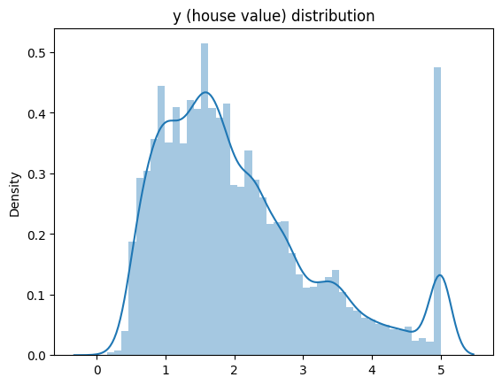

```python
sns.distplot(y,kde=True)
plt.title("y (house value) distribution")
plt.show()
```

Skewed Distribution: The distribution appears right-skewed, meaning there are more houses with lower values and fewer houses with higher values.

Multiple Modes: The distribution is multimodal with several peaks, which suggests that there are clusters of house values. This might indicate that houses tend to group around certain value ranges which could be due to regional differences in house prices, types of housing, or other factors.

Outliers: There is a noticeable spike at the far right end of the distribution, around 5. This could indicate a presence of outliers in the data, or it could represent a cap on house values in the dataset (such as a maximum value set for data collection purposes).

Overall, the data may require preprocessing to account for its non-normal distribution and potential outliers before it is used in predictive modeling.

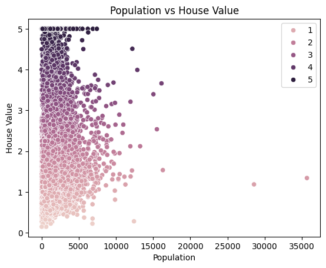

```python
sns.scatterplot(x=X["Population"],y=y,hue=y)
plt.title("Population vs House Value")
plt.ylabel("House Value")
plt.show()
```

House Value Capping: There's a clear horizontal line at the house value of 5, which suggests that house values have been capped at this number in the dataset, as mentioned earlier regarding the distribution plot.

Population Size: The majority of data points seem to cluster at the lower end of the population axis, indicating that most of the areas have a smaller population.

Lack of Strong Correlation: There does not seem to be a strong, clear relationship between population size and house value. Higher population does not necessarily correlate with higher or lower house values.

Outliers: There are few areas with very high populations, and these do not show a corresponding increase in house value, suggesting that higher population densities may not be a driver of higher property values in this dataset.

Hue Variation: The points are colored (hue) based on house value, which provides additional visualization of the distribution of house values. Darker points, representing higher house values, do not show a pattern of clustering around certain population sizes.

Data Density: It seems like there's a higher density of points where both the population and the house values are lower, suggesting that most of the data fall into the lower-end market in less densely populated areas.

Overall, population size alone may not be a strong predictor of house value

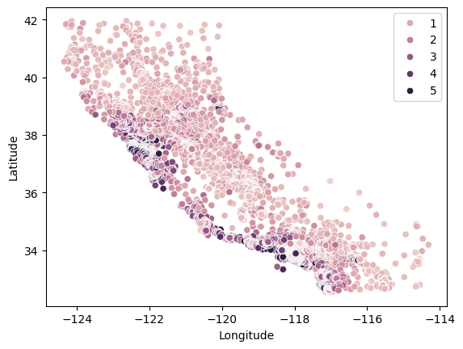

```python
sns.scatterplot(x=X["Longitude"], y=X["Latitude"],hue=y,legend=True)
plt.show()
```

Geographic Distribution: The points are clearly representing the geographical shape of California. This suggests that the data includes a wide representation across the state.

Value Distribution: The variation in hue indicates the distribution of house values across different geographical locations. There's no single area that appears to be exclusively high or low in value; rather, there's a mix throughout, with perhaps some clustering of similar values.

Coastal Influence: It looks like there are darker points (which indicate higher house values) closer to the coast, particularly around the Bay Area and Southern California coast, which is consistent with the known higher property values in those areas.

Inland Values: Inland areas seem to have a mix of values but tend to feature more of the lighter hues, suggesting that house values might be lower away from the coast.

Urban vs Rural: There may be denser clusters of darker hues corresponding to urban areas, where house values are typically higher.

Outliers: There are some outliers in terms of location. That coast area has low house value.

Overall, location could be a potential predictor for house value.

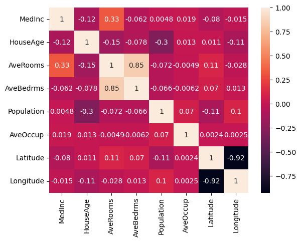

```python
sns.heatmap(X.corr(),annot=True)
```

Strong Positive Correlations: The most notable strong positive correlation is between AveRooms (average number of rooms) and AveBedrms (average number of bedrooms), which is intuitive because a larger number of rooms often implies more bedrooms.

Strong Negative Correlations: There is a strong negative correlation between Latitude and Longitude, which may indicate a geographical pattern across California where as you move north-south or east-west, certain housing characteristics consistently change.

Weak Correlations: Variables like Population, HouseAge, AveOccup, and MedInc have very weak correlations with most other variables

Potential Multicollinearity: The strong correlation between AveRooms and AveBedrms might indicate multicollinearity if they are both used as predictors in a linear regression model, which could inflate variances.

Geographic Coordinates as Predictors: The strong negative correlation between the geographic coordinates could be utilized to identify location-specific trends or patterns in the housing market

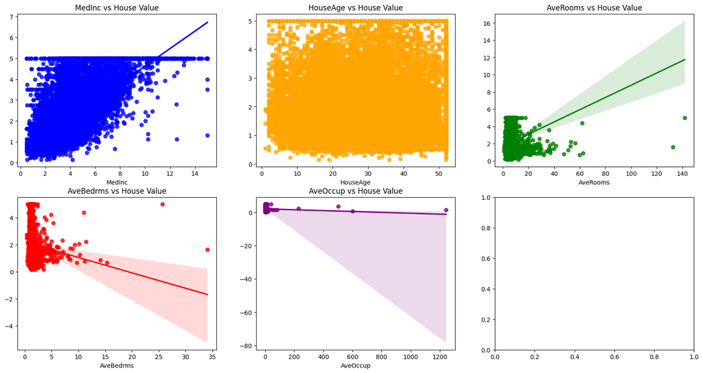

```python
fig, axes = plt.subplots(nrows=2, ncols=3, figsize=(20, 10))
sns.regplot(x=X["MedInc"], y=y, color="blue",line_kws={'color': 'blue'},ax=axes[0][0])
axes[0][0].set_title("MedInc vs House Value")
sns.regplot(x=X["HouseAge"], y=y, color="orange",line_kws={'color': 'orange'},ax=axes[0][1])
axes[0][1].set_title("HouseAge vs House Value")
sns.regplot(x=X["AveRooms"], y=y, color="green",line_kws={'color': 'green'},ax=axes[0][2])
axes[0][2].set_title("AveRooms vs House Value")
sns.regplot(x=X["AveBedrms"], y=y, color="red",line_kws={'color': 'red'},ax=axes[1][0])
axes[1][0].set_title("AveBedrms vs House Value")
sns.regplot(x=X["AveOccup"], y=y, color="purple",line_kws={'color': 'purple'},ax=axes[1][1])
axes[1][1].set_title("AveOccup vs House Value")
```

Median Income vs House Value (blue plot): There seems to be a positive linear relationship between median income and house value. As median income increases, house value tends to increase as well. This suggests that median income is a strong predictor of house value.

House Age vs House Value (orange plot): There is no apparent linear relationship between the age of the house and its value. The data points are widely dispersed, and the regression line is nearly horizontal, which suggests that house age might not be a significant predictor of house value in this dataset.

Average Rooms vs House Value (green plot): There is a potential positive linear relationship indicating that houses with more rooms tend to have higher values. This plot also shows that the relationship may not be strictly linear as the confidence interval widens for houses with a very high number of rooms, indicating more variability in house value in that range.

Average Bedrooms vs House Value (red plot): This plot indicates a potential negative linear relationship, which might seem counterintuitive. It's possible that this reflects a situation where houses with too many bedrooms relative to their overall size (or compared to the number of rooms) are less valued, or another variable influencing the relationship.

Average Occupancy vs House Value (purple plot): The potential negative relationship here suggests that as average occupancy increases, house value tends to decrease. Higher occupancy could be associated with rental properties or crowded housing, which might be less valued in the market.

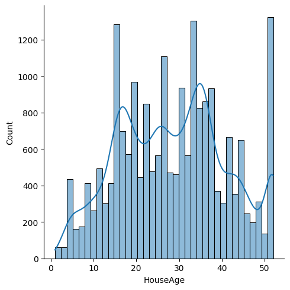

```python
sns.displot(X["HouseAge"],kde=True)
plt.show()
```

Multiple Peaks: The distribution shows several peaks, indicating that the age of houses in this dataset is multimodal. These peaks may correspond to periods of increased building activity.

Spread of Ages: There's a wide spread of house ages, from new to possibly over 50 years old.

Variability in Older Houses: There's increased variability in the number of houses as age increases, which is evident from the wider bars and peaks in the histogram.

Kernel Density Estimate (KDE): The KDE line, which estimates the probability density function of the HouseAge variable, follows the shape of the histogram but smooths out some of the variability, suggesting the overall pattern of ages is not uniform.

Possible Outliers: The long bars at the far right of the histogram could indicate outliers in the age of houses.

High-Frequency Ages: Certain age values have particularly high frequencies, which could indicate common ages.

```python
from sklearn.preprocessing import StandardScaler
from sklearn.model_selection import train_test_split
from sklearn.neural_network import MLPRegressor
from sklearn.metrics import r2_score
scale = StandardScaler()
X = scale.fit_transform(X)

X_train, X_test, y_train, y_test = train_test_split(X, y , test_size=0.3, random_state=42)
mlp = MLPRegressor(hidden_layer_sizes=(130,64,32,16),activation="relu", max_iter=500)
mlp.fit(X_train, y_train)
predictions = mlp.predict(X_test)
print(f"Testing R^2 Score: {r2_score(y_test,predictions)}")
print(f"Training R^2 Score: {r2_score(y_train,mlp.predict(X_train))}")
```

```
Testing R^2 Score: 0.7925043413502111
Training R^2 Score: 0.8919502936683521
```

My testing score is 0.793 and training score is 0.892. Not bad at all.

```python
mlp_2 = MLPRegressor(hidden_layer_sizes=(13,13,13,13),activation="relu", max_iter=500)
mlp_2.fit(X_train, y_train)
predictions_2 = mlp_2.predict(X_test)
print(f"Testing R^2 Score: {r2_score(y_test,predictions_2)}")
print(f"Training R^2 Score: {r2_score(y_train,mlp_2.predict(X_train))}")
```

```
Testing R^2 Score: 0.7871683815644004
Training R^2 Score: 0.8104100792136552
```

In the step above, I keep 4 hidden layers but assign only 13 neurons for each layer. We can see the testing score drops 0.006 (from 0.793 to 0.787), and the training score drops 0.082 (from 0.892 to 0.81).

Decreasing the number of neurons of hidden layers could decrease both testing and training score.

```python
mlp_3 = MLPRegressor(hidden_layer_sizes=(13,),activation="relu", max_iter=500)
mlp_3.fit(X_train, y_train)
predictions_3 = mlp_3.predict(X_test)
print(f"Testing R^2 Score: {r2_score(y_test,predictions_3)}")
print(f"Training R^2 Score: {r2_score(y_train,mlp_3.predict(X_train))}")
```

```
Testing R^2 Score: 0.7517626348756249
Training R^2 Score: 0.7599944599097136
```

In the step above, I reduce the number of hidden layer to only 1 with 13 neurons. The testing score drops 0.041 from the first one (from 0.793 to 0.752), and the training score drops 0.132 from the first one (from 0.892 - 0.76).

Decreasing the number of hidden layer and the neurons of them could decrease both testing and training score. However, it affects the training score more since with lower number of hidden layer or lower number of neurons, the neural network couldn't deep-learn effectively as the neural network with more number of hidden layer or number of neuron.

```python
mlp_4 = MLPRegressor(hidden_layer_sizes=(256,130,64,32,16),activation="relu", max_iter=500)
mlp_4.fit(X_train, y_train)
predictions_4 = mlp_4.predict(X_test)
print(f"Testing R^2 Score: {r2_score(y_test,predictions_4)}")
print(f"Trainging R^2 Score: {r2_score(y_train,mlp_4.predict(X_train))}")
```

```
Testing R^2 Score: 0.7678529262641076
Trainging R^2 Score: 0.9588963520034588
```

In the step above, I increase the number of hidden layer from 4 to 5 with their number of neuron [256,130,64,32,16]. The testing score drops 0.024 from the first one (from 0.792 to 0.768). However, the training score increases 0.067 from the first one (from 0.892 to 0.959).

Increasing the number of hidden layer and the number of neuron in them could make the model to deep-learn better. However, it could lead to overfitting when the model learns the training data too well, but does badly with the testing data.

Overall, hidden_layer_size determine how deep the model can learn from the data.

```python
from sklearn.model_selection import GridSearchCV
params = {
    'hidden_layer_sizes': [(50,), (100,), (50, 50), (100, 100)],
    'activation': ['identity', 'logistic','tanh', 'relu'],
    'solver': ['lbfgs','sgd', 'adam'],
    'alpha': [0.0001, 0.001, 0.01, 0.1],
    'learning_rate_init': [0.001, 0.01,0.1],
    'learning_rate': ['constant', 'invscaling', 'adaptive'],
}
grid_search = GridSearchCV(estimator=MLPRegressor(max_iter=1000),param_grid=params,n_jobs=-1, cv=5, scoring='r2', verbose=10)
grid_search.fit(X_train,y_train)
print("Best parameters found:")
print(grid_search.best_params_)

best_model = grid_search.best_estimator_
print("Training score:", best_model.score(X_train, y_train))
print("Test score:", best_model.score(X_test, y_test))
```

```
Fitting 5 folds for each of 1728 candidates, totalling 8640 fits
```

In the step above, I try to set some parameters for the neural network model. However, I was greedy to set a lot of parameter in order to cover a broad GridSearch while my computer doesn't allow me to run the code. It took hours but didn't finish.

```python
params = {
    'hidden_layer_sizes': [(50,), (100,), (50, 50), (100, 100)],
    'activation': ['tanh', 'relu'],
    'solver': ['sgd', 'adam'],
    'alpha': [0.0001, 0.001],
    'learning_rate_init': [0.001, 0.01,0.1],
}
grid_search = GridSearchCV(estimator=MLPRegressor(max_iter=1000),param_grid=params,n_jobs=-1, cv=5, scoring='r2', verbose=10)
grid_search.fit(X_train,y_train)
print("Best parameters found:")
print(grid_search.best_params_)

best_model = grid_search.best_estimator_
print("Training score:", best_model.score(X_train, y_train))
print("Test score:", best_model.score(X_test, y_test))
```

```
Fitting 5 folds for each of 96 candidates, totalling 480 fits
```

[output not shown]

```
Best parameters found:
{'activation': 'tanh', 'alpha': 0.001, 'hidden_layer_sizes': (100, 100), 'learning_rate_init': 0.001, 'solver': 'adam'}
Training score: 0.8228311371372977
Test score: 0.796172338004834
```

In the step above, I decrease the number of parameter for the GridSearch.

After a while, best parameters found: {'activation': 'tanh', 'alpha': 0.001, 'hidden_layer_sizes': (100, 100), 'learning_rate_init': 0.001, 'solver': 'adam'} with Training score: 0.8228311371372977 and Test score: 0.796172338004834

As we can see the testing score increases 0.003 from the first one (from 0.793 to 0.796) and the training score drops 0.07 from the first one (from 0.893 to 0.823).

The "hidden_layer_sizes" is decreases from (130,64,32,16) to (100,100) but we have higher testing score, which proved that "hidden_layer_sizes" is not a major parameter. Dropping number of hidden layer also decreases the training score, which is proved in this step.

```python
from sklearn.model_selection import train_test_split, GridSearchCV
from sklearn.preprocessing import StandardScaler
from sklearn.datasets import fetch_california_housing
from sklearn.neural_network import MLPRegressor
from sklearn.metrics import r2_score
california = fetch_california_housing()
X = pd.DataFrame(california.data, columns=california.feature_names)
y = pd.Series(california.target)

for feature in ["MedInc", "AveRooms", "AveBedrms", "AveOccup", "Population"]:
    Q1 = X[feature].quantile(0.25)
    Q3 = X[feature].quantile(0.75)
    IQR = Q3 - Q1
    lower_bound = Q1 - 1.5 * IQR
    upper_bound = Q3 + 1.5 * IQR

    mask = (X[feature] >= lower_bound) & (X[feature] <= upper_bound)
    X = X[mask]
    y = y[mask]

scaler = StandardScaler()
X=scaler.fit_transform(X)

X_train, X_test, y_train, y_test = train_test_split(X, y , test_size=0.3, random_state=42)
mlp = MLPRegressor(hidden_layer_sizes=(130,64,32,16),activation="relu", max_iter=500)
mlp.fit(X_train, y_train)
predictions = mlp.predict(X_test)
print(f"Testing R^2 Score: {r2_score(y_test,predictions)}")
print(f"Training R^2 Score: {r2_score(y_train,mlp.predict(X_train))}")
```

```
Testing R^2 Score: 0.7427175877782983
Training R^2 Score: 0.913889976205533
```

In the step above, I tried to drop all the outliers from every columns using the IQR method.

It could be the sign of overfitting, after dropping the outliers, the neural network now fits the training data better, hence the higher training score.This suggests that the outliers in the original dataset may have been providing a sort of regularization effect, helping the model generalize better to unseen data by not "overfitting" to the idiosyncrasies in the training data. However, these outliers could sometimes be extreme values that still carry important information, and removing them can lead to a loss of information that was useful for prediction. Or if outliers are a natural part of the real-world data (not errors or anomalies), removing them creates a training set that no longer represents the reality as accurately, which can lead to worse performance on real-world data

```python
params = {
    'hidden_layer_sizes': [(50,), (100,), (50, 50), (100, 100)],
    'activation': ['tanh', 'relu'],
    'solver': ['sgd', 'adam'],
    'alpha': [0.0001, 0.001],
    'learning_rate_init': [0.001, 0.01,0.1],
}
grid_search = GridSearchCV(estimator=MLPRegressor(max_iter=1000),param_grid=params,n_jobs=-1, cv=5, scoring='r2', verbose=10)
grid_search.fit(X_train,y_train)
print("Best parameters found:")
print(grid_search.best_params_)

best_model = grid_search.best_estimator_
print("Training score:", best_model.score(X_train, y_train))
print("Test score:", best_model.score(X_test, y_test))
```

```
Fitting 5 folds for each of 96 candidates, totalling 480 fits
Best parameters found:
{'activation': 'tanh', 'alpha': 0.001, 'hidden_layer_sizes': (100, 100), 'learning_rate_init': 0.001, 'solver': 'adam'}
Training score: 0.8905155719042837
Test score: 0.7443755814160053
```

Using the same GridSearch from the first one, the best parameters found for the model is the same also. Best parameters found: {'activation': 'tanh', 'alpha': 0.001, 'hidden_layer_sizes': (100, 100), 'learning_rate_init': 0.001, 'solver': 'adam'}

```python
from sklearn import datasets
iris = datasets.load_iris()
X = pd.DataFrame(data=iris.data,columns=iris.feature_names)
y= iris.target
```

```python
X.describe()
```

|  | sepal length (cm) | sepal width (cm) | petal length (cm) | petal width (cm) |
| --- | --- | --- | --- | --- |
| count | 150.000000 | 150.000000 | 150.000000 | 150.000000 |
| mean | 5.843333 | 3.057333 | 3.758000 | 1.199333 |
| std | 0.828066 | 0.435866 | 1.765298 | 0.762238 |
| min | 4.300000 | 2.000000 | 1.000000 | 0.100000 |
| 25% | 5.100000 | 2.800000 | 1.600000 | 0.300000 |
| 50% | 5.800000 | 3.000000 | 4.350000 | 1.300000 |
| 75% | 6.400000 | 3.300000 | 5.100000 | 1.800000 |
| max | 7.900000 | 4.400000 | 6.900000 | 2.500000 |

```python
X.info()
```

```
<class 'pandas.core.frame.DataFrame'>
RangeIndex: 150 entries, 0 to 149
Data columns (total 4 columns):
 #   Column             Non-Null Count  Dtype
---  ------             --------------  -----
 0   sepal length (cm)  150 non-null    float64
 1   sepal width (cm)   150 non-null    float64
 2   petal length (cm)  150 non-null    float64
 3   petal width (cm)   150 non-null    float64
dtypes: float64(4)
memory usage: 4.8 KB
```

```python
X["species"] = y
X
```

|  | sepal length (cm) | sepal width (cm) | petal length (cm) | petal width (cm) | species |
| --- | --- | --- | --- | --- | --- |
| 0 | 5.1 | 3.5 | 1.4 | 0.2 | 0 |
| 1 | 4.9 | 3.0 | 1.4 | 0.2 | 0 |
| 2 | 4.7 | 3.2 | 1.3 | 0.2 | 0 |
| 3 | 4.6 | 3.1 | 1.5 | 0.2 | 0 |
| 4 | 5.0 | 3.6 | 1.4 | 0.2 | 0 |
| ... | ... | ... | ... | ... | ... |
| 145 | 6.7 | 3.0 | 5.2 | 2.3 | 2 |
| 146 | 6.3 | 2.5 | 5.0 | 1.9 | 2 |
| 147 | 6.5 | 3.0 | 5.2 | 2.0 | 2 |
| 148 | 6.2 | 3.4 | 5.4 | 2.3 | 2 |
| 149 | 5.9 | 3.0 | 5.1 | 1.8 | 2 |

150 rows × 5 columns

```python
X.describe()
```

|  | sepal length (cm) | sepal width (cm) | petal length (cm) | petal width (cm) | species |
| --- | --- | --- | --- | --- | --- |
| count | 150.000000 | 150.000000 | 150.000000 | 150.000000 | 150.000000 |
| mean | 5.843333 | 3.057333 | 3.758000 | 1.199333 | 1.000000 |
| std | 0.828066 | 0.435866 | 1.765298 | 0.762238 | 0.819232 |
| min | 4.300000 | 2.000000 | 1.000000 | 0.100000 | 0.000000 |
| 25% | 5.100000 | 2.800000 | 1.600000 | 0.300000 | 0.000000 |
| 50% | 5.800000 | 3.000000 | 4.350000 | 1.300000 | 1.000000 |
| 75% | 6.400000 | 3.300000 | 5.100000 | 1.800000 | 2.000000 |
| max | 7.900000 | 4.400000 | 6.900000 | 2.500000 | 2.000000 |

```python
X.info()
```

```
<class 'pandas.core.frame.DataFrame'>
RangeIndex: 150 entries, 0 to 149
Data columns (total 5 columns):
 #   Column             Non-Null Count  Dtype
---  ------             --------------  -----
 0   sepal length (cm)  150 non-null    float64
 1   sepal width (cm)   150 non-null    float64
 2   petal length (cm)  150 non-null    float64
 3   petal width (cm)   150 non-null    float64
 4   species            150 non-null    int32
dtypes: float64(4), int32(1)
memory usage: 5.4 KB
```

```python
X.isna().sum()
```

```
sepal length (cm)    0
sepal width (cm)     0
petal length (cm)    0
petal width (cm)     0
species              0
dtype: int64
```

There is no missing value. we could see that with the info() method using for the dataset ("non-null" in every column). Also, using isna() methods help us check missing values.

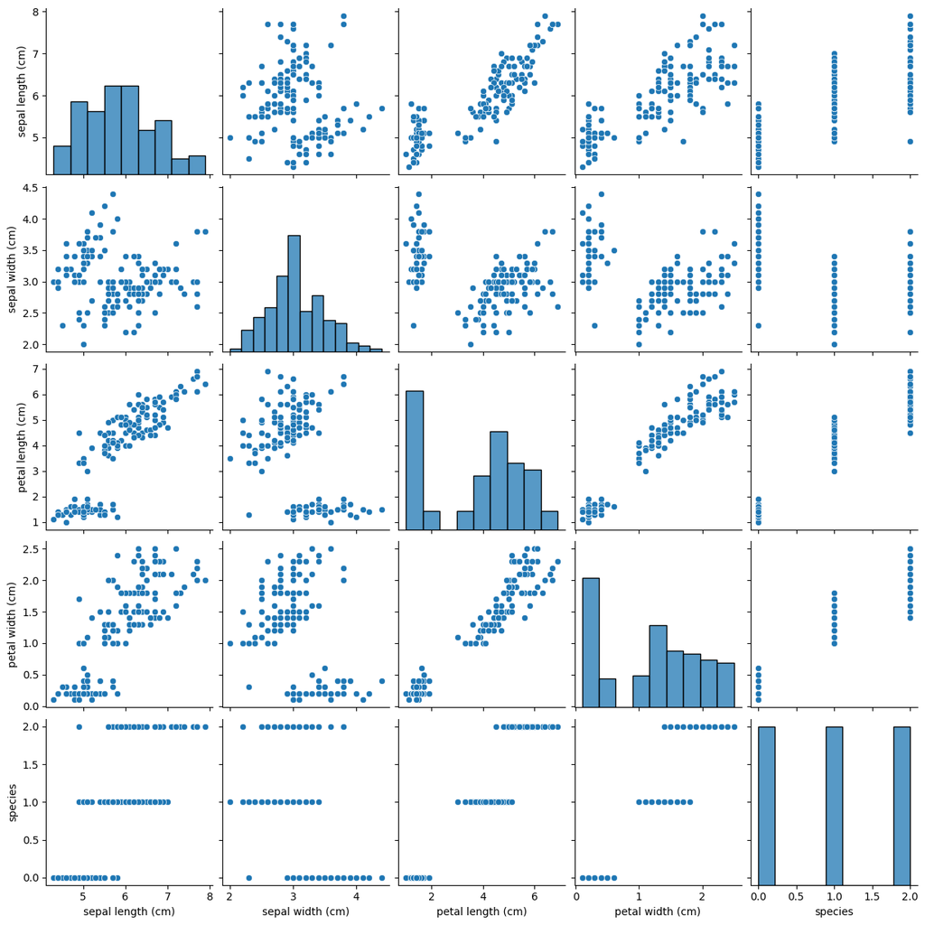

```python
sns.pairplot(X)
```

The pairplot you've created for the Iris dataset is a matrix of plots giving us the pairwise relationships between different measurements across the different species of iris flowers. Each row and column correspond to the four features of the dataset: sepal length, sepal width, petal length, and petal width. The diagonal shows the distribution of each variable for all species combined. Here's what we can deduce:

Petal Length and Width (strong positive correlation): There is a strong positive correlation between petal length and petal width. The points form a clear linear pattern, suggesting that as petal length increases, petal width also tends to increase.

Separation of Species: When looking at the scatter plots involving petal length and petal width, it seems possible to distinguish between species based on these two features alone. One species (likely setosa, based on common characteristics of the dataset) is clearly separable from the other two, which could be versicolor and virginica, based on its much smaller petal lengths and widths.

Overlap of Species: The other two species overlap in the scatter plots involving sepal length and width, suggesting that these features are not as effective for species discrimination on their own.

Distribution Shapes: The histograms on the diagonal suggest that sepal width and sepal length follow a roughly normal distribution, whereas petal length and petal width show a bimodal distribution, likely reflecting the distinct characteristics of the iris species.

Sepal Length and Width (weak correlation): Sepal length and width have a less pronounced correlation, as indicated by a more diffuse cloud of points in their scatter plot.

Overall, it appears that petal measurements provide the best separation between species, while sepal measurements are less distinctive on their own

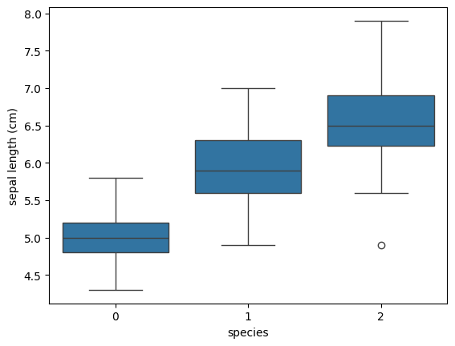

```python
sns.boxplot(x=X["species"],y=X["sepal length (cm)"],legend=True)
```

Species 0: This species has the smallest median sepal length and the distribution is tight with a small interquartile range (IQR). There are no outliers and the whiskers are relatively short, which suggests that the sepal lengths for this species are quite consistent.

Species 1: The median sepal length is greater than that of species 0, with a slightly larger IQR indicating more variability in sepal length within this species. The whiskers are longer than those for species 0, showing that the data for sepal length is more spread out.

Overall, there is a clear distinction in the median sepal length among the three species, with each subsequent species having a longer median sepal length than the previous. The presence of an outlier in species 2 suggests some specimens may not follow the general pattern.

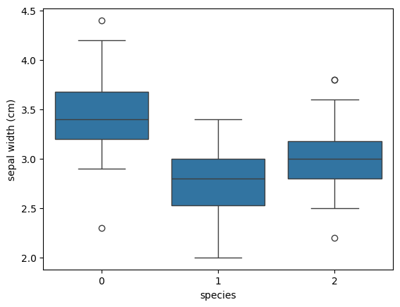

```python
sns.boxplot(x=X["species"],y=X["sepal width (cm)"],legend=True)
```

Species 0: This species has a higher median sepal width compared to the other two species. The interquartile range (IQR) is tight, but there are also outliers on both the lower and higher ends, indicating some specimens with exceptionally narrow or wide sepals.

Species 1: This species has the lowest median but same IQR as specie 0 . The whiskers (which represent the range of the data excluding outliers) are slightly longer than those of species 0 and 2, suggesting more variability. There is no outlier.

Species 2: The median sepal width of this species is between that of species 0 and 1, but closer to species 1. The interquartile range is the narrowest. There are also outliers on both the lower and higher ends, indicating some specimens with exceptionally narrow or wide sepals.

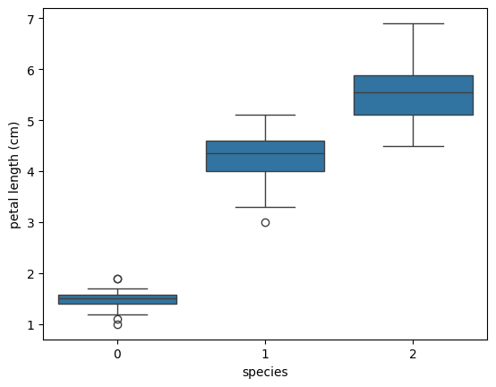

```python
sns.boxplot(x=X["species"],y=X["petal length (cm)"],legend=True)
```

Species 1: The median petal length for this species is around 4 cm, much longer than that of species 0. The IQR is larger than in species 0, suggesting more variability in petal length within this species. There's one outlier that has a shorter petal length.

Species 2: This species has the longest petals, with the median around 5.5 cm. The IQR is slightly larger to that of species 1, but the overall range of petal lengths is greater, as indicated by the longer whiskers.

Overall, Species 0 has significantly shorter petal length than the other two species, which can be a distinctive feature for classification purposes.

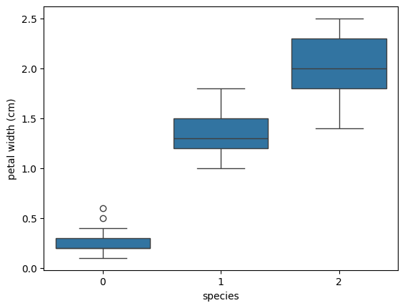

```python
sns.boxplot(x=X["species"],y=X["petal width (cm)"],legend=True)
```

Species 1: The median petal width for this species is around 1.3 cm, much longer than that of species 0. The IQR is larger than in species 0, suggesting more variability in petal width within this species. There is no outlier.

Species 2: This species has the longest petals, with the median around 2.1 cm. The IQR is larger to that of species 1, the overall range of petal widths is greater, as indicated by the longer whiskers.

Overall, Species 0 has significantly shorter petal width than the other two species, which can be a distinctive feature for classification purposes.

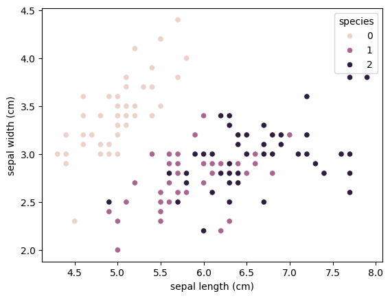

```python
sns.scatterplot(x=X["sepal length (cm)"],y=X["sepal width (cm)"],hue=X["species"])
```

Species Differentiation: It seems possible to somewhat distinguish between the three species based on sepal dimensions, although there's more overlap between species 1 and 2 compared to the clear distinction from species 0.

Species 0: This species is generally characterized by shorter and wider sepals compared to the other two species. The points are clustered in the lower sepal length and higher sepal width region of the plot.

Species 1 and 2: These species have longer sepals compared to species 0. There's some overlap between these two species, but on average, species 2 may have wider sepals than species 1.

Spread and Overlap: The scatterplot indicates that while sepal length increases across species, the sepal width does not have a straightforward relationship with species. The spread of data points within species 1 and 2 suggests variability and less distinct separation based on sepal width alone.

Potential Outliers: There are some points that stand out from the main clusters which could be considered outliers, or they may represent natural variation within the species.

Overall, sepal length can be a distinguishing feature, though sepal width has more variability and less differentiation capability between species 1 and 2.

```python
from sklearn.preprocessing import StandardScaler
from sklearn.model_selection import train_test_split
from sklearn.neural_network import MLPClassifier
from sklearn.metrics import accuracy_score

X.drop(labels=["species"],axis=1,inplace=True)

scale = StandardScaler()
X = scale.fit_transform(X)

X_train, X_test, y_train, y_test = train_test_split(X,y,test_size=0.3,random_state=42)
mlp = MLPClassifier(hidden_layer_sizes=[256,128,64,32],activation='relu')
mlp.fit(X_train, y_train)
predictions = mlp.predict(X_test)
print(f"Testing Accuracy Score: {accuracy_score(y_test,predictions)}")
print(f"Training Accuracy Score: {accuracy_score(y_train,mlp.predict(X_train))}")
```

```
Testing Accuracy Score: 0.9777777777777777
Training Accuracy Score: 1.0
```

We got almost perfect model.

```python
mlp_2 = MLPClassifier(hidden_layer_sizes=[13,13,13,13],activation='relu')
mlp_2.fit(X_train, y_train)
predictions_2 = mlp_2.predict(X_test)
print(f"Testing Accuracy Score: {accuracy_score(y_test,predictions_2)}")
print(f"Training Accuracy Score: {accuracy_score(y_train,mlp_2.predict(X_train))}")
```

```
Testing Accuracy Score: 1.0
Training Accuracy Score: 0.9619047619047619
```

In this situation, decreasing the number of neurons of hidden layers could decrease training score but not testing score. Which could be explained by that with lower number of neuron in each hidden layers, the model couldn't learn the training as deep (effectively) as the the model with more number of neurons, but it could have no effect on the testing score.

```python
mlp_3 = MLPClassifier(hidden_layer_sizes=[13,],activation='relu')
mlp_3.fit(X_train, y_train)
predictions_3 = mlp_3.predict(X_test)
print(f"Testing Accuracy Score: {accuracy_score(y_test,predictions_3)}")
print(f"Training Accuracy Score: {accuracy_score(y_train,mlp_3.predict(X_train))}")
```

```
Testing Accuracy Score: 0.8
Training Accuracy Score: 0.8
```

Decreasing the number of hidden layer and the neurons of them could decrease both testing and training score.

```python
mlp_4 = MLPClassifier(hidden_layer_sizes=[512,256,128,64,32],activation='relu')
mlp_4.fit(X_train, y_train)
predictions_4 = mlp_4.predict(X_test)
print(f"Testing Accuracy Score: {accuracy_score(y_test,predictions_4)}")
print(f"Training Accuracy Score: {accuracy_score(y_train,mlp_4.predict(X_train))}")
```

```
Testing Accuracy Score: 0.9777777777777777
Training Accuracy Score: 1.0
```

Increasing the number of hidden layer and the number of neuron in them could make the model to deep-learn better. However, it could lead to overfitting when the model learns the training data too well, but does badly with the testing data if we keep increasing the number of hidden layer or number of neuron.

```python
from sklearn.model_selection import GridSearchCV
params = {
    'hidden_layer_sizes': [(50,), (100,), (50, 50), (100, 100),[256,128,64,32]],
    'activation': ['tanh', 'relu'],
    'solver': ['sgd', 'adam'],
    'alpha': [0.0001, 0.001, 0.01, 0.1],
    'learning_rate_init': [0.001, 0.01,0.1],
}
grid_search = GridSearchCV(estimator=MLPClassifier(max_iter=1000),param_grid=params,n_jobs=-1, cv=10, scoring='accuracy', verbose=10)
grid_search.fit(X_train,y_train)
print("Best parameters found:")
print(grid_search.best_params_)

best_model = grid_search.best_estimator_
print("Training score:", best_model.score(X_train, y_train))
print("Test score:", best_model.score(X_test, y_test))
```

```
Fitting 10 folds for each of 240 candidates, totalling 2400 fits
Best parameters found:
{'activation': 'tanh', 'alpha': 0.0001, 'hidden_layer_sizes': (50,), 'learning_rate_init': 0.01, 'solver': 'sgd'}
Training score: 0.9523809523809523
Test score: 0.9777777777777777
```

The Best parameters found: {'activation': 'tanh', 'alpha': 0.0001, 'hidden_layer_sizes': (50,), 'learning_rate_init': 0.01, 'solver': 'sgd'}.

However, the model we got use much less computational power with only one hidden layer with 50 neurons. The reasons is we got "solver" as "sgd", "sgd" is simple but effective, while "adam" may be more computationally intensive. Also, "tanh" is quickly converge than sigmoid and logistic function.

```python
from sklearn.metrics import confusion_matrix
confusion_matrix(y_test,predictions)
```

[output not shown]

F1 Score: The F1 score for class 1 and class 2 would be slightly lower than 1 due to the precision-recall trade-off, but for class 0, it would be perfect.